# Project #1

Кравчик Константин

17.08.2019

## Загрузка и подготовка данных

Грузим датасет:

```r
# Clear the R workspace
rm(list=ls())
# Close all devices
if (!is.null(dev.list())) {dev.off()}
```

```r
# Load R libraries
library(data.table)
# Load data
dt<-fread(file = "orders.csv",sep=",",header = F,na.strings = "\\N", nrows = 2194778)
# Name columns
# DT_L - Date and time lead
# ID_L - ID lead
# DT_APP - Date and time of the approve
# DT_CALL - Date call
# ID_WM - ID of a web-master
# PRODUCT - Product
# LOGIN_O - Login of an operator
# SEX_O - sex of an operator
# AGE_O - age of an soperator
# COUNTRY_O - country of an operator
names(dt)<-c("DT_L","ID_L","DT_APP","DT_CALL","ID_WM","PRODUCT","LOGIN_O","SEX_O","AGE_O","COUNTRY_O")
# Print part od data
head(dt)
```

```
##                   DT_L     ID_L              DT_APP DT_CALL
## 1: 2017-08-24 10:26:25 21409266 2017-08-24 16:39:42    <NA>
## 2: 2017-08-24 10:26:27 21409268 2017-08-25 12:19:40    <NA>
## 3: 2017-08-24 10:26:27 21409268 2017-08-25 12:19:40    <NA>
## 4: 2017-08-24 10:27:40 21409317 2017-08-24 16:27:46    <NA>
## 5: 2017-08-24 10:27:50 21409321 2017-08-24 18:30:12    <NA>
## 6: 2017-08-24 10:28:35 21409344 2017-08-24 18:06:27    <NA>
##                               ID_WM        PRODUCT LOGIN_O SEX_O AGE_O
## 1: 59de92f6d28f32d15fd2201911d27a2e Hammer of Thor    <NA>  <NA>    NA
## 2: 0267c547f3f524e35f55fbae55c8ef89     Goji cream    <NA>  <NA>    NA
## 3: 0267c547f3f524e35f55fbae55c8ef89     Goji cream    <NA>  <NA>    NA
## 4: 16d7a0d3c19927918bdae40e95489913      X-Power M    <NA>  <NA>    NA
## 5: 739bda9f4a402fe737f80a3b392a6027   Energy Saver    <NA>  <NA>    NA
## 6: c84b56703b03ca166c9e3d6d937b9d30         Upsize    <NA>  <NA>    NA
##    COUNTRY_O
## 1:      <NA>
## 2:      <NA>
## 3:      <NA>
## 4:      <NA>
## 5:      <NA>
## 6:      <NA>
```

Данные мы загрузили.

Сейчас выберем только требуемые колонки:

```r
library(dplyr)
dt<-dt %>% select(DT_L,ID_L,DT_APP,DT_CALL,PRODUCT,COUNTRY_O)
head(dt)
```

```
##                   DT_L     ID_L              DT_APP DT_CALL        PRODUCT
## 1: 2017-08-24 10:26:25 21409266 2017-08-24 16:39:42    <NA> Hammer of Thor
## 2: 2017-08-24 10:26:27 21409268 2017-08-25 12:19:40    <NA>     Goji cream
## 3: 2017-08-24 10:26:27 21409268 2017-08-25 12:19:40    <NA>     Goji cream
## 4: 2017-08-24 10:27:40 21409317 2017-08-24 16:27:46    <NA>      X-Power M
## 5: 2017-08-24 10:27:50 21409321 2017-08-24 18:30:12    <NA>   Energy Saver
## 6: 2017-08-24 10:28:35 21409344 2017-08-24 18:06:27    <NA>         Upsize
##    COUNTRY_O
## 1:      <NA>
## 2:      <NA>
## 3:      <NA>
## 4:      <NA>
## 5:      <NA>
## 6:      <NA>
```

Как мы видим, некоторые обязательные переменные имеют отсутствующее значение. Для построения моделей нам нужны все данные. Таким образом, мы удалим все строки, у которых пропущенные значения.

```r
dt<-dt %>% na.omit()
head(dt)
```

```
##                   DT_L     ID_L              DT_APP             DT_CALL
## 1: 2017-08-25 22:54:30 21480059 2019-06-08 00:35:54 2019-06-07 00:15:10
## 2: 2017-08-25 22:54:30 21480059 2019-06-08 00:35:54 2019-06-08 00:23:38
## 3: 2017-08-27 02:38:59 21528725 2019-05-30 23:16:26 2019-05-30 23:04:51
## 4: 2017-08-27 02:38:59 21528725 2019-05-30 23:16:26 2019-05-30 23:05:34
## 5: 2017-08-29 05:50:15 21626575 2019-06-02 00:04:27 2019-06-01 23:55:38
## 6: 2017-08-29 05:50:15 21626575 2019-06-02 00:04:27 2019-06-01 23:56:01
##       PRODUCT COUNTRY_O
## 1: Goji berry  Colombia
## 2: Goji berry  Colombia
## 3: Goji cream  Colombia
## 4: Goji cream  Colombia
## 5:  Titan Gel  Colombia
## 6:  Titan Gel  Colombia
```

Посмотрим на итоговую размерность датасета:

```r
cat("The dimension is:", dim(dt),"\n")
```

[output not shown]

Хорошо. Сейчас у нас 696640 наблюдений. Это очень хороший объем для сборки любой модели.

Теперь мы добавим метки (1), если было апрувлено, и (0) в другом случае.

```r
dt<-dt %>% group_by(ID_L) %>% mutate(CLASS=c(rep(0,length(DT_CALL)-1),1)) %>% data.table()
head(dt)
```

```
##                   DT_L     ID_L              DT_APP             DT_CALL
## 1: 2017-08-25 22:54:30 21480059 2019-06-08 00:35:54 2019-06-07 00:15:10
## 2: 2017-08-25 22:54:30 21480059 2019-06-08 00:35:54 2019-06-08 00:23:38
## 3: 2017-08-27 02:38:59 21528725 2019-05-30 23:16:26 2019-05-30 23:04:51
## 4: 2017-08-27 02:38:59 21528725 2019-05-30 23:16:26 2019-05-30 23:05:34
## 5: 2017-08-29 05:50:15 21626575 2019-06-02 00:04:27 2019-06-01 23:55:38
## 6: 2017-08-29 05:50:15 21626575 2019-06-02 00:04:27 2019-06-01 23:56:01
##       PRODUCT COUNTRY_O CLASS
## 1: Goji berry  Colombia     0
## 2: Goji berry  Colombia     1
## 3: Goji cream  Colombia     0
## 4: Goji cream  Colombia     1
## 5:  Titan Gel  Colombia     0
## 6:  Titan Gel  Colombia     1
```

Удалим ID_L.

```r
dt<-dt %>% select(-c(ID_L))
head(dt)
```

```
##                   DT_L              DT_APP             DT_CALL    PRODUCT
## 1: 2017-08-25 22:54:30 2019-06-08 00:35:54 2019-06-07 00:15:10 Goji berry
## 2: 2017-08-25 22:54:30 2019-06-08 00:35:54 2019-06-08 00:23:38 Goji berry
## 3: 2017-08-27 02:38:59 2019-05-30 23:16:26 2019-05-30 23:04:51 Goji cream
## 4: 2017-08-27 02:38:59 2019-05-30 23:16:26 2019-05-30 23:05:34 Goji cream
## 5: 2017-08-29 05:50:15 2019-06-02 00:04:27 2019-06-01 23:55:38  Titan Gel
## 6: 2017-08-29 05:50:15 2019-06-02 00:04:27 2019-06-01 23:56:01  Titan Gel
##    COUNTRY_O CLASS
## 1:  Colombia     0
## 2:  Colombia     1
## 3:  Colombia     0
## 4:  Colombia     1
## 5:  Colombia     0
## 6:  Colombia     1
```

Посмотрим на распределение классов:

```r
table(dt$CLASS)/nrow(dt)
```

```
##
##        0        1
## 0.670652 0.329348
```

Здесь мы видим, что класс 0 появляется в 2 раза чаще. Мы должны помнить это в будущем.

## Task #1

Здесь мы можем попытаться предсказать оптимальное время звонка и оценить вероятность этого случая. Вероятно, эти случаи будут более одного, потому что наша функция приближения является мультимодальной нелинейной функцией.

Для прогнозирования необходимых данных мы установим 3 значения:

- DT_L - Date andTime of the lead;
- PRODUCT - The commodity;
- COUNTRY - The country

Мы можем загрузить эти данные из любого файла или установить их вручную.

Установим вручную:

```r
# Set values
mainV<-data.table(DT_L="2019-04-04 21:28:55",
                  PRODUCT="Titan Gel",
                  COUNTRY_O="Guatemala")
# Convert Date and Time to Date-time format
mainV$DT_L<-as.POSIXct(x = mainV$DT_L,format="%Y-%m-%d %H:%M:%S")
```

Get sub-data set using filtering by PRODUCT and COUNTRY_O

```r
s_dt<-dt %>% filter(PRODUCT==mainV$PRODUCT,COUNTRY_O==mainV$COUNTRY_O)
head(s_dt)
```

```
##                  DT_L              DT_APP             DT_CALL   PRODUCT
## 1 2018-11-29 10:55:56 2019-05-08 00:34:31 2018-11-30 00:12:26 Titan Gel
## 2 2018-11-29 10:55:56 2019-05-08 00:34:31 2018-11-30 00:12:32 Titan Gel
## 3 2018-11-29 10:55:56 2019-05-08 00:34:31 2018-12-13 21:19:31 Titan Gel
## 4 2018-11-29 10:55:56 2019-05-08 00:34:31 2018-12-21 19:23:11 Titan Gel
## 5 2018-11-29 10:55:56 2019-05-08 00:34:31 2018-12-28 20:47:55 Titan Gel
## 6 2018-11-29 10:55:56 2019-05-08 00:34:31 2019-05-08 00:03:52 Titan Gel
##   COUNTRY_O CLASS
## 1 Guatemala     0
## 2 Guatemala     0
## 3 Guatemala     0
## 4 Guatemala     0
## 5 Guatemala     0
## 6 Guatemala     0
```

```r
cat("The dimension is:",dim(s_dt),"\n")
```

[output not shown]

У нас 22107. достаточно для построения модели.

Пока переменные продукт и страна нам не нужны:

```r
s_dt<-s_dt %>% select(-c(PRODUCT,COUNTRY_O))
head(s_dt)
```

```
##                  DT_L              DT_APP             DT_CALL CLASS
## 1 2018-11-29 10:55:56 2019-05-08 00:34:31 2018-11-30 00:12:26     0
## 2 2018-11-29 10:55:56 2019-05-08 00:34:31 2018-11-30 00:12:32     0
## 3 2018-11-29 10:55:56 2019-05-08 00:34:31 2018-12-13 21:19:31     0
## 4 2018-11-29 10:55:56 2019-05-08 00:34:31 2018-12-21 19:23:11     0
## 5 2018-11-29 10:55:56 2019-05-08 00:34:31 2018-12-28 20:47:55     0
## 6 2018-11-29 10:55:56 2019-05-08 00:34:31 2019-05-08 00:03:52     0
```

Take difference between DT_L and DT_CALL and replace these 2 variables by one:

```r
s_dt$DT_L<-as.POSIXct(x = s_dt$DT_L,format="%Y-%m-%d %H:%M:%S")
s_dt$DT_CALL<-as.POSIXct(x = s_dt$DT_CALL,format="%Y-%m-%d %H:%M:%S")
s_dt$DIFF<-s_dt$DT_CALL-s_dt$DT_L
s_dt<-s_dt %>% select(-c(DT_L, DT_CALL))
head(s_dt)
```

```
##                DT_APP CLASS          DIFF
## 1 2019-05-08 00:34:31     0    47790 secs
## 2 2019-05-08 00:34:31     0    47796 secs
## 3 2019-05-08 00:34:31     0  1247015 secs
## 4 2019-05-08 00:34:31     0  1931235 secs
## 5 2019-05-08 00:34:31     0  2541119 secs
## 6 2019-05-08 00:34:31     0 13784876 secs
```

Посмотрите на график для разницы между датой и временем:

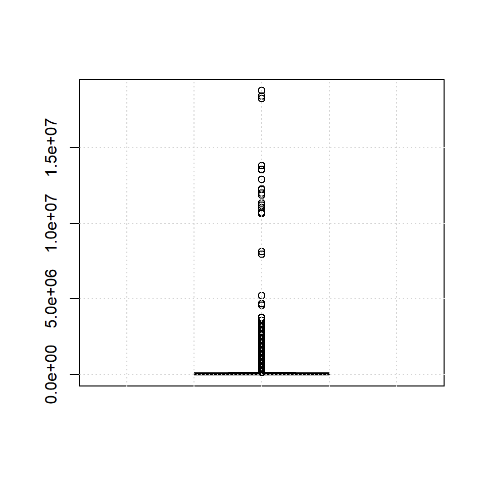

```r
res<-boxplot(as.numeric(s_dt$DIFF))
grid()
```

Есть выбросы. Для создания модели лучше всего их исправить. Мы заменим их средними значениями.

```r
indV<-which(as.numeric(s_dt$DIFF) %in% res$out)
s_dt$DIFF[indV]<-mean(s_dt$DIFF[-indV])
head(s_dt)
```

```
##                DT_APP CLASS         DIFF
## 1 2019-05-08 00:34:31     0 47790.0 secs
## 2 2019-05-08 00:34:31     0 47796.0 secs
## 3 2019-05-08 00:34:31     0 31915.3 secs
## 4 2019-05-08 00:34:31     0 31915.3 secs
## 5 2019-05-08 00:34:31     0 31915.3 secs
## 6 2019-05-08 00:34:31     0 31915.3 secs
```

Хорошо. У нас есть один двоичный ответ и один предиктор. Для нахождения оптимальной вероятности звонка мы можем использовать классификатор Random Forest. Эта модель может очень хорошо аппроксимировать нелинейные и мультимодальные зависимости.

Строим модель:

```r
library(randomForest) # Load for Random Forest building
library(MLmetrics) # Metrics for test accuracy
set.seed(100) # For reproducive results
# Here we get indexies for 1 and 0 classes
pos0<-which(s_dt$CLASS==0)
pos1<-which(s_dt$CLASS==1)
# Find the minimum number of classes
min_l<-min(c(length(pos0),length(pos1)))
# Resample data for balancing of classes
pos0<-sample(x = pos0,size = min_l,replace = T)
pos1<-sample(x = pos1,size = min_l,replace = T)
# Get resampled data set
s_dt2<-s_dt[c(pos0,pos1),]
m<-randomForest(x = data.table(DIFF=as.numeric(s_dt2$DIFF)),y = as.factor(s_dt2$CLASS),ntree = 500)
# Print the main results of this model
print(m)
```

```
##
## Call:
##  randomForest(x = data.table(DIFF = as.numeric(s_dt2$DIFF)), y = as.factor(s_dt2$CLASS),      ntree = 500)
##                Type of random forest: classification
##                      Number of trees: 500
## No. of variables tried at each split: 1
##
##         OOB estimate of  error rate: 29.67%
## Confusion matrix:
##      0    1 class.error
## 0 3761 1572   0.2947684
## 1 1593 3740   0.2987062
```

Здесь мы видим, что каждый класс был прогнозируемым приемлемым.

Выведем основную точность, используя выборочные и несэмплированные данные:

```r
pr2<-predict(object = m,newdata = data.table(DIFF=as.numeric(s_dt2$DIFF)))
cat("The accuracy of sampled data:",100*Accuracy(y_pred = s_dt2$CLASS,y_true = pr2),"%\n")
```

[output not shown]

```r
pr<-predict(object = m,newdata = data.table(DIFF=as.numeric(s_dt$DIFF)))
real_ac<-100*Accuracy(y_pred = s_dt$CLASS,y_true = pr)
cat("The accuracy of unsampled:",real_ac,"%\n")
```

[output not shown]

**Хорошо. Мы получили ~ 70% точности для реальных данных. Это хорошие результаты. То есть с вероятностью 70% мы можем сказать, когда вызов должен быть сделан для утверждения.**

Найти оптимальное время для звонка. Шаг времени должен быть не менее 1 секунды. Мы установили 5 минут. Мы создадим таблицу прогнозирования на 24 часа вперед.

```r
# Создаем временные шаги
difV<-seq(0,24*60*60,5*60)
# Predict each time steps
prob_pos<-predict(object = m,newdata = data.table(DIFF=difV),type = "prob")[,2]
# Create required table:
res<-data.table(DT_LD=mainV$DT_L,DT_CALL=mainV$DT_L+difV,PROB_APP=round(100*prob_pos,2),
                PROB_APP_РЎ=round(prob_pos*real_ac,2))
res<-res %>% arrange(-PROB_APP)
head(res,8)
```

```
##                 DT_LD             DT_CALL PROB_APP PROB_APP_РЎ
## 1 2019-04-04 21:28:55 2019-04-04 21:28:55    100.0      70.21
## 2 2019-04-04 21:28:55 2019-04-05 11:18:55    100.0      70.21
## 3 2019-04-04 21:28:55 2019-04-05 12:43:55    100.0      70.21
## 4 2019-04-04 21:28:55 2019-04-05 12:53:55    100.0      70.21
## 5 2019-04-04 21:28:55 2019-04-05 01:18:55     99.8      70.07
## 6 2019-04-04 21:28:55 2019-04-05 08:13:55     99.8      70.07
## 7 2019-04-04 21:28:55 2019-04-05 08:33:55     99.8      70.07
## 8 2019-04-04 21:28:55 2019-04-04 23:28:55     99.6      69.93
```

**Здесь мы видим лучшие 8 случаев даты-времени звонка и вероятности одобрения. Конечно 100% это только в теории. В действительности это будет не более 70% (PROB_APP_C). Это апостериорная вероятность. Немного справки по запросу Артёма: Априорная вероятность – это оценка вероятности будущего события, рассчитанная моделью. Ну, например, что будет аппрув. Пусть это будет p. У нас также есть оценка точности модели на тестовых данных. Пусть она будет q. Тогда апостериорную вероятность можно посчитать так: f=p*q То есть если бы для всех аппрувов, модель оценивала вероятность аппрува в 100%, но на тестовых данных показывала бы 70%, согласитель, что мы бы доверяли её лишь в 70%. Вот для этого я сделал дополнительный столбец с поправкой. Где оценка вероятности перемножается с вероятностью успешного прогноза PROB_APP – это оценка будущего события моделью. То есть оценка вероятности того, что будет аппрув. Второй столбец – это вероятность аппрува с поправкой. Я считаю он более корректен (то есть мы там получаем апостериорные вероятности с учетом результатов тестирования модели). Обычно этого никто не делает. Поэтому для Вас это может показаться непонятным и странным. Но, согласитесь, когда мы знаем, как реально работает модель, мы можем еще и внести поправки к результатам оценки вероятностей этой моделью. То есть они становятся менее оптимистичными. Да и вообще в реальности 100% вероятностей прогноза быть не может. Вообщем Таблица выше - это оценки вероятностей аппрува после заданного времени звонка. Это делает модель. Случайный лес.Здесь все сделано за 5 минут. Шаг 5 минут.Это прогнозы когда делать звонки и с какой вероятностью будет аппрув для заданного времени.**

Попробуем посмотреть, как зависит вероятность одобрения от даты и времени звонка.

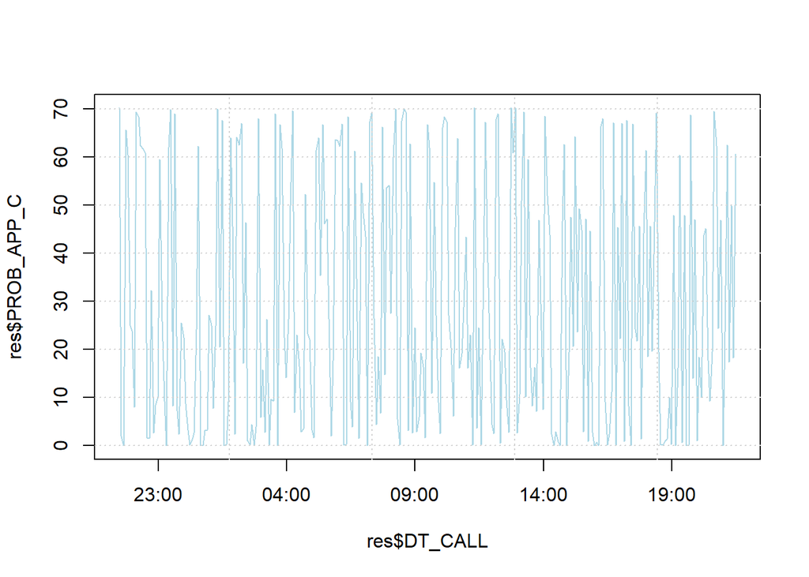

```r
res<-res %>% arrange(res$DT_CALL)
plot(x = res$DT_CALL,y = res$PROB_APP_РЎ,type="l", col="lightblue")
grid()
```

As we can see it is nonlinear multi-modal dependence.

## Task #2

Здесь задача состоит в том, чтобы установить ПРОДУКТ и СТРАНУ и получить таблицу, в которой мы видим среднее время подтверждения,% и количество звонков в час.

Задача решается статистическим способом

зададим значения вручную:

```r
# Set values
mainV<-data.table(PRODUCT="Titan Gel",
                  COUNTRY_O="Guatemala")
```

Ok. Now we will take the sub-data set for these PRODUCT and COUNTRY_O.

```r
s_dt<-dt %>% filter(PRODUCT==mainV$PRODUCT,COUNTRY_O==mainV$COUNTRY_O)
head(s_dt)
```

```
##                  DT_L              DT_APP             DT_CALL   PRODUCT
## 1 2018-11-29 10:55:56 2019-05-08 00:34:31 2018-11-30 00:12:26 Titan Gel
## 2 2018-11-29 10:55:56 2019-05-08 00:34:31 2018-11-30 00:12:32 Titan Gel
## 3 2018-11-29 10:55:56 2019-05-08 00:34:31 2018-12-13 21:19:31 Titan Gel
## 4 2018-11-29 10:55:56 2019-05-08 00:34:31 2018-12-21 19:23:11 Titan Gel
## 5 2018-11-29 10:55:56 2019-05-08 00:34:31 2018-12-28 20:47:55 Titan Gel
## 6 2018-11-29 10:55:56 2019-05-08 00:34:31 2019-05-08 00:03:52 Titan Gel
##   COUNTRY_O CLASS
## 1 Guatemala     0
## 2 Guatemala     0
## 3 Guatemala     0
## 4 Guatemala     0
## 5 Guatemala     0
## 6 Guatemala     0
```

```r
cat("The dimension is:",dim(s_dt),"\n")
```

```
## The dimension is: 22107 6
```

Хорошо. Теперь мы возьмем только часовую часть из переменных даты и времени (включая дату и время утверждения):

```r
library(lubridate) # for working with dates
s_dt$DT_CALL<-as.POSIXct(x = s_dt$DT_CALL,format="%Y-%m-%d %H:%M:%S")
s_dt$DT_L<-as.POSIXct(x = s_dt$DT_L,format="%Y-%m-%d %H:%M:%S")
s_dt$DT_APP<-as.POSIXct(x = s_dt$DT_APP,format="%Y-%m-%d %H:%M:%S")
s_dt$DT_CALL<-hour(x = s_dt$DT_CALL)
s_dt$DT_L<-hour(x = s_dt$DT_L)
```

Все готово чтобы создать таблицу:

```r
library(knitr)
# Take only approved calls
s_dt<-s_dt %>% filter(CLASS==1)
s_dt<-s_dt %>% select(-c(DT_L,PRODUCT,COUNTRY_O,CLASS))
table1<-s_dt %>% group_by(DT_CALL) %>% summarise(MEAN_DT_APP=as.ITime(mean(as.ITime(DT_APP))),
                                                 N_CALLS=n())
table1$P_CALLS<-table1$N_CALLS/sum(table1$N_CALLS)
table1 %>% kable()
```

| DT_CALL | MEAN_DT_APP | N_CALLS | P_CALLS |
| --- | --- | --- | --- |
| 0 | 01:07:01 | 398 | 0.0746297 |
| 1 | 02:23:26 | 350 | 0.0656291 |
| 2 | 03:47:20 | 241 | 0.0451903 |
| 3 | 07:51:37 | 3 | 0.0005625 |
| 14 | 15:19:54 | 1 | 0.0001875 |
| 15 | 15:43:47 | 178 | 0.0333771 |
| 16 | 16:49:51 | 483 | 0.0905682 |
| 17 | 17:48:06 | 807 | 0.1513220 |
| 18 | 18:45:59 | 647 | 0.1213201 |
| 19 | 19:45:21 | 540 | 0.1012563 |
| 20 | 20:36:26 | 505 | 0.0946934 |
| 21 | 21:33:09 | 416 | 0.0780049 |
| 22 | 21:46:30 | 376 | 0.0705044 |
| 23 | 17:22:38 | 388 | 0.0727545 |

Здесь мы видим, что среднее время подтверждения (MEAN_DT_APP) составляет 01:07:01, если мы звоним через 0 часов, 02:23:26, если мы звоним через 1 час и т. Д. Кроме того, мы видим вызовы # и% для каждого часа. P_CALLS – это не вероятности, а частоты совершения звонков. То есть данные во сколько и сколько звонков совершается и есть частота этих звонков. Чем больше звонков – тем больше частота: P_CALLS= N_CALLS(i)/(Сумма N_CALLS)

Хорошо. Посмотрим на эту таблицу по количеству вызовов.

```r
table1<-table1 %>% arrange(-N_CALLS)
table1 %>% kable()
```

| DT_CALL | MEAN_DT_APP | N_CALLS | P_CALLS |
| --- | --- | --- | --- |
| 17 | 17:48:06 | 807 | 0.1513220 |
| 18 | 18:45:59 | 647 | 0.1213201 |
| 19 | 19:45:21 | 540 | 0.1012563 |
| 20 | 20:36:26 | 505 | 0.0946934 |
| 16 | 16:49:51 | 483 | 0.0905682 |
| 21 | 21:33:09 | 416 | 0.0780049 |
| 0 | 01:07:01 | 398 | 0.0746297 |
| 23 | 17:22:38 | 388 | 0.0727545 |
| 22 | 21:46:30 | 376 | 0.0705044 |
| 1 | 02:23:26 | 350 | 0.0656291 |
| 2 | 03:47:20 | 241 | 0.0451903 |
| 15 | 15:43:47 | 178 | 0.0333771 |
| 3 | 07:51:37 | 3 | 0.0005625 |
| 14 | 15:19:54 | 1 | 0.0001875 |

As we can see 17 hour is the pick of calls. look at this table based on bar plot by hours.

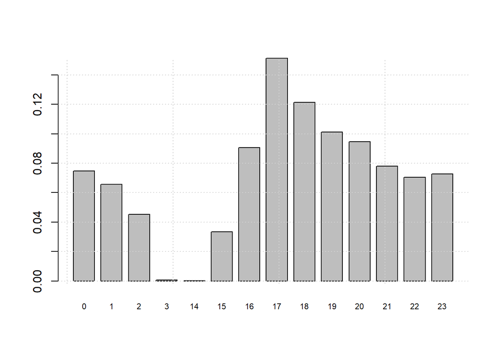

```r
table1<-table1 %>% arrange(DT_CALL)
barplot(height =  table1$P_CALLS,names.arg = table1$DT_CALL,space = 0.3,cex.names = 0.7)
grid()
```

**Здесь мы видим очень низкую нагрузку на 3 и 14 часов. Причем статистики за 4-13 часов нет. Вероятно, для этого продукта и страны нет нагрузки.**

## Conclusion

Задача № 1 была решена с использованием Random Forest и дает нам приемлемую вероятность звонков. Задача № 2 решена на основе статистических методов.